# hw2 solutions

Rushal Sohal; github: rushalsohal

02/07/2020

## R commands

1. 24F and 15F to celsius and stored in vector *cel*

```r
cel <- c((24-32)*5/9, (15-32)*5/9)
cel
```

```
## [1] -4.444444 -9.444444
```

2. Vector *vec200* with even entries as 1 and odd as 3

*Assuming we start counting from 1 and not 0*

```r
vec200 <- 0
for (i in 1:200) {
  if(i%%2==0)
    vec200[i] = 1
  else
    vec200[i] = 3
}
vec200
```

```
##   [1] 3 1 3 1 3 1 3 1 3 1 3 1 3 1 3 1 3 1 3 1 3 1 3 1 3 1 3 1 3 1 3 1 3 1 3 1 3
##  [38] 1 3 1 3 1 3 1 3 1 3 1 3 1 3 1 3 1 3 1 3 1 3 1 3 1 3 1 3 1 3 1 3 1 3 1 3 1
##  [75] 3 1 3 1 3 1 3 1 3 1 3 1 3 1 3 1 3 1 3 1 3 1 3 1 3 1 3 1 3 1 3 1 3 1 3 1 3
## [112] 1 3 1 3 1 3 1 3 1 3 1 3 1 3 1 3 1 3 1 3 1 3 1 3 1 3 1 3 1 3 1 3 1 3 1 3 1
## [149] 3 1 3 1 3 1 3 1 3 1 3 1 3 1 3 1 3 1 3 1 3 1 3 1 3 1 3 1 3 1 3 1 3 1 3 1 3
## [186] 1 3 1 3 1 3 1 3 1 3 1 3 1 3 1
```

3. perfect squares between 1 and 2001

```r
numPerfect <- round(sqrt(2001)) - 1
numPerfect
```

```
## [1] 44
```

## Cars and mileage

```r
if(!require('ggplot2'))
  install.packages('ggplot2')
```

1. What are the 3 most fuel-efficient models in terms of highway mileage? Storage the data frame (with 3 rows) containing all information of these three cars in a variable named `top3` and print.

**Answer:** *Higher hwy mileage = Better fuel efficiency*

The most-fuel efficient cars are Volkswagen Jetta (manual), Volkswagen New Beetle(manual), and Volkswagen New Beetle(automatic).

There are numerous ways to find the highest value in a column. Nevertheless, I first sorted the column and then picked the top 3 values of hwy mileage (44,44,41). Using these values, I found the car details with a *which* statement.

```r
tmp <- sort(mpg$hwy, decreasing=TRUE)
top3 <- mpg[c(which(mpg$hwy == tmp[1]), which(mpg$hwy == tmp[3])),]
top3
```

```
## # A tibble: 3 x 11
##   manufacturer model   displ  year   cyl trans   drv     cty   hwy fl    class
##   <chr>        <chr>   <dbl> <int> <int> <chr>   <chr> <int> <int> <chr> <chr>
## 1 volkswagen   jetta     1.9  1999     4 manual… f        33    44 d     compact
## 2 volkswagen   new be…   1.9  1999     4 manual… f        35    44 d     subcom…
## 3 volkswagen   new be…   1.9  1999     4 auto(l… f        29    41 d     subcom…
```

2. How many different compact models are included in this dataset? Storage the answer in a variable named `numCompact` and print.

**Answer:** There are 47 different compact models. Using *which*, I found the values in *mpg_class* where the class equaded *compact*

```r
numCompact <- length(which(mpg$class == 'compact'))
numCompact
```

```
## [1] 47
```

3. Create a scatterplot of `hwy` and `cty` and describe the relationship. Why are there so few points visible? Explain your findings.

**Answer:** The graph of City vs Highway is a linearly increasing curve (or a strong positive correlation). We don’t see a lot of points due to redundancy, i.e., highway and city only have 27 and 21 unique values, respectively (out of 234 data values).

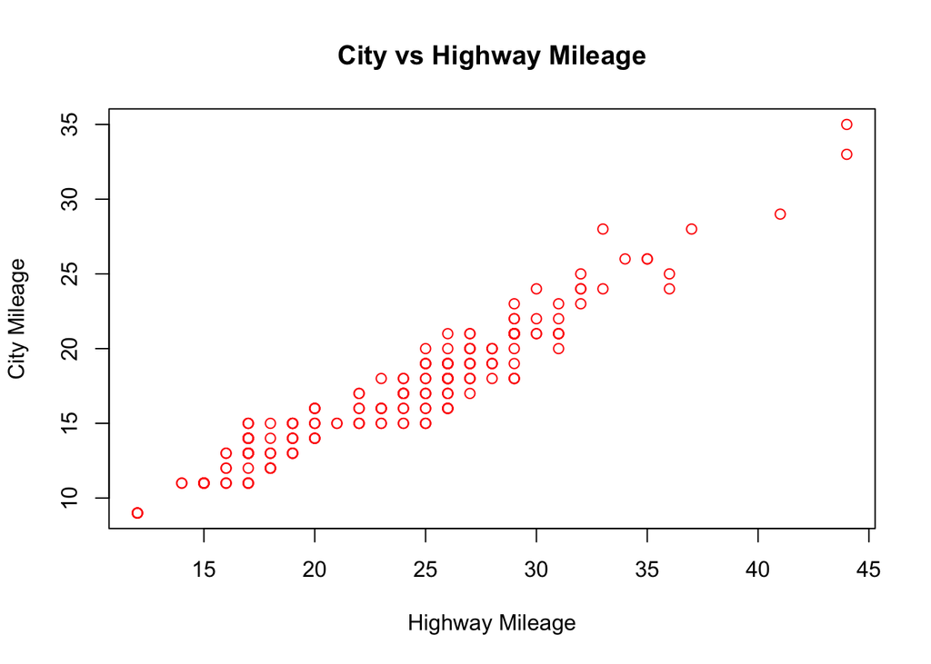

```r
plot(mpg$hwy, mpg$cty, main="City vs Highway Mileage", xlab="Highway Mileage", ylab="City Mileage", col="red")
```

```r
length(unique(mpg$hwy))
```

```
## [1] 27
```

```r
length(unique(mpg$cty))
```

```
## [1] 21
```

4. Are cars in 2008 more fuel efficient than cars in 1999? Use graphs *and* summary statistics to answer this question. Explain your findings.

**Answer:** *Fuel efficiency is only decided based on hwy mileage*

```r
library(dplyr)
mpg %>% group_by(year) %>% summarise(avg = mean(hwy))
```

```
## # A tibble: 2 x 2
##    year   avg
##   <int> <dbl>
## 1  1999  23.4
## 2  2008  23.5
```

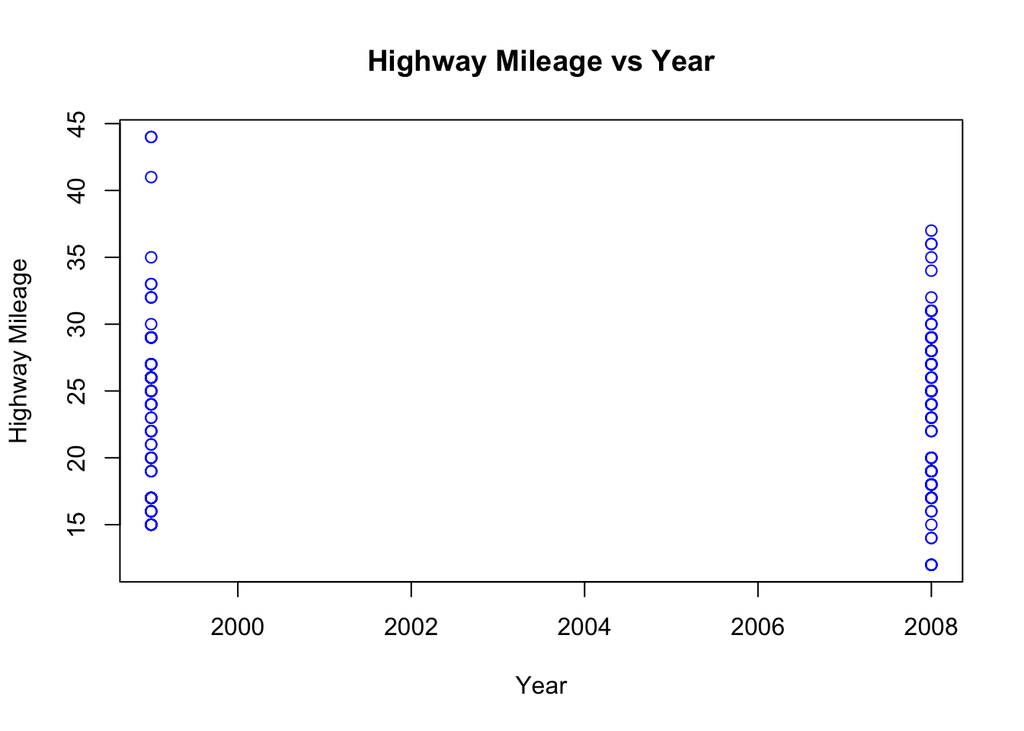

```r
plot(mpg$year, mpg$hwy, main="Highway Mileage vs Year", xlab="Year", ylab="Highway Mileage", col="blue", type="p")
```